# Impacts of Major Natural Disasters on American Communities

Alyssa Girard, Akillesh Suresh, Kaya Williams

2025-12-11

## Introduction

### How Does Extreme Weather, Wildfires, and Floods Affect Human Welfare and Economics in the United States?

Communities across the United States face increasing and ongoing disaster risks, resulting in impacts on how individuals live and the economic growth potential of those communities. This study aims to answer the question: How do extreme weather, wildfires, and floods affect human welfare and economics in the United States? These hazards represent the largest volume and most expensive disasters in our nation. As climate change increases their frequency and intensity, it is essential to assess the detrimental impacts they create. The information gained from examining the residual impacts of these natural disasters will help identify the areas in our country likely to be most adversely affected and the demographic groups that will bear the greatest risks. The results will provide the information needed to establish policies and plans to prepare for future natural disasters.

To answer this complex question, we developed several follow-up questions that examine different dimensions of human and economic impact. We asked how rates of respiratory symptoms change after natural disasters, as disasters can disrupt air quality, healthcare access, and environmental conditions. Next, we evaluated how much natural disasters affect the U.S. economy by examining inflation-adjusted damages over time. Because damages vary widely across the country, we also asked which U.S. regions experience the highest economic losses, allowing us to assess geographic exposure and vulnerability. Finally, we investigated which disasters cause the most deaths and which result in the highest rates of homelessness, two key indicators of how disasters directly affect human lives and long-term community stability.

Together, these follow-up questions allow us to examine the problem from multiple angles: health, mortality, homelessness, geography, and financial loss. By combining these perspectives, we can better understand how extreme weathers, wildfires, and floods shape human welfare and economic resilience across the United States.

## Data & Data Sources

### Natural Disasters: Our World in Data

- Our first data source is from Our World in Data’s Natural Disasters dataset.
- It contains data from multiple types of disasters and impacts (e.g., deaths, injuries, homelessness, etc.) and the year each disaster occurred.
- This dataset is pre-processed by Our World in Data. They aggregate information from several major institutions rather than collecting it themselves.
- Their data originates from internationally recognized sources including the OECD, World Bank, WHO, United Nations agencies, research institutes such as PRIO, peer-reviewed academic publications, and official government statistics.
- Possible limitations:
  - Some countries and years may have missing or incomplete disaster reporting.
  - Mortality and impact data may vary depending on historical reporting quality.
  - Combining different disaster types into categories (e.g., “extreme weather”) may introduce classification bias.
- Link: https://ourworldindata.org/natural-disasters#explore-data-on-natural-disasters

### Losses from Natural Disasters: Federal Reserve Bank of New York

- Our second data source is the Federal Reserve Bank of New York’s Losses from Natural Disasters dataset, which describes direct economic damages from natural disasters across U.S. counties.
- The dataset uses pre-processed county-level damage estimates developed by the NY Fed using FEMA, insurance filings, federal declarations, and historical disaster records.
- Validity Considerations:
  - Damage values are inflation-adjusted and standardized, making them reliable for long-term comparison.
  - Some counties may underreport damages, especially rural or low-population areas.
  - Economic loss calculations involve modeling and estimation, so values may contain measurement bias or uncertainty.
- Because this dataset is maintained by a federal institution, it is considered a high-credibility data source.
- Link: https://www.newyorkfed.org/research/policy/natural-disaster-losses/#interactive

### A Weekly Influenza Surveillance Report: CDC

- Our third data source is the CDC’s Weekly Influenza Surveillance Report, which tracks the level of respiratory-related emergency department visits.
- This dataset is collected directly by the CDC, using hospital networks, clinical laboratories, and physician reporting systems.
- Data validity considerations:
  - Reporting is consistent nationwide, but spikes in disease reporting may reflect healthcare access rather than true illness rates.
  - Some reporting delays or missing data can occur during natural disasters when hospitals are disrupted.
  - The dataset reflects reported illnesses, not total illnesses, which could introduce systematic undercounting.
- Because this dataset is maintained by a government organization, it is considered a high-credibility data source.
- Link: https://gis.cdc.gov/grasp/fluview/main.html

```r
# Create a data dictionary as a data frame
data_dictionary <- data.frame(
  Variable_Name = c(
    "Entity", "Year", "Deaths - Flood", "Deaths - Extreme weather",
    "Deaths - Earthquake", "Homeless", "Injured", "fips",
    "event_type", "begin_date", "damages_total_adj", "county", "state",
    "Week_of", "COVID-like Illness", "RSV-like Illness", "Influenza",
    "Combined_Count", "RPHO_REGION", "WEEKENDING"
  ),
  Description = c(
    "Country or region represented in the dataset.",
    "Year of the recorded disaster event.",
    "Number of deaths caused by floods in a given year.",
    "Number of deaths from extreme weather events.",
    "Number of deaths caused by earthquakes.",
    "Number of people left homeless due to a disaster.",
    "Number of people injured due to disasters.",
    "County FIPS code identifying U.S. counties.",
    "Type of natural disaster.",
    "Date when the disaster event began.",
    "Inflation-adjusted total economic damages for the event.",
    "County where the event occurred.",
    "State where the county is located.",
    "Date the weekly reporting period begins.",
    "Emergency visits classified as COVID-like illness.",
    "Emergency visits classified as RSV-like illness.",
    "Emergency visits associated with influenza.",
    "Total emergency department visits across illness types.",
    "Public Health Region identifier.",
    "End date of the reporting week."
  )
)
```

## Results

### How do rates of respiratory symptoms change after natural disasters?

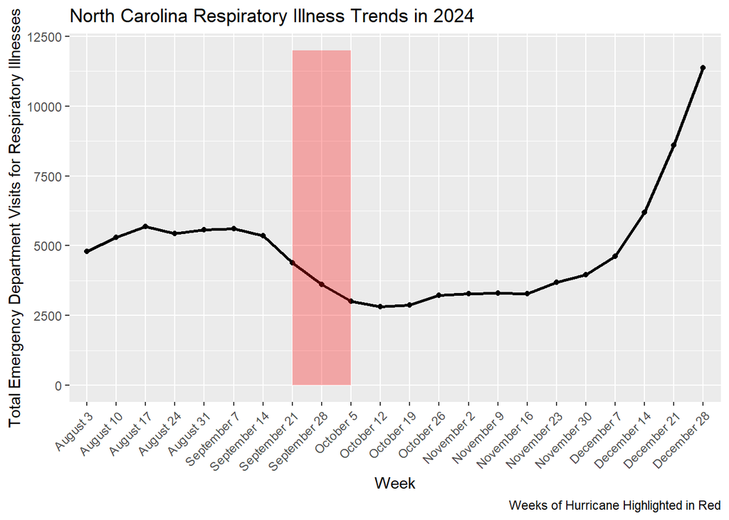

```r
nc<- read_csv(here("data/OverallCounts_tidy.csv"))


nc<- nc[31:52,]

nc <- nc %>%
  rename(Covid_like_illness = "COVID-like Illness",
         RSV_like_illness = "RSV-like Illness") %>%
  separate(Week_of, c("Date","Year"), sep = ',') %>%
  mutate(total = Covid_like_illness + RSV_like_illness + Influenza) %>%
  select(-2)

nc$Date <- as.character(nc$Date)
nc$Date <- factor(nc$Date, levels=unique(nc$Date))

helene_illness <- ggplot(data = nc, aes(x = Date, y = total))+
  geom_line(linewidth = 1, na.rm = T, aes(group=1))+
  geom_point()+
  theme(axis.text.x = element_text(angle = 45, hjust=1))+
  labs(x = "Week",
       y = "Total Emergency Department Visits for Respiratory Illnesses",
       title = "North Carolina Respiratory Illness Trends in 2024",
       caption= "Weeks of Hurricane Highlighted in Red")

helene_illness <- helene_illness + annotate("rect", xmin = "September 21", xmax = "October 5", ymin = 0, ymax = 12000,
             alpha = 0.3, fill = "red")

helene_illness
```

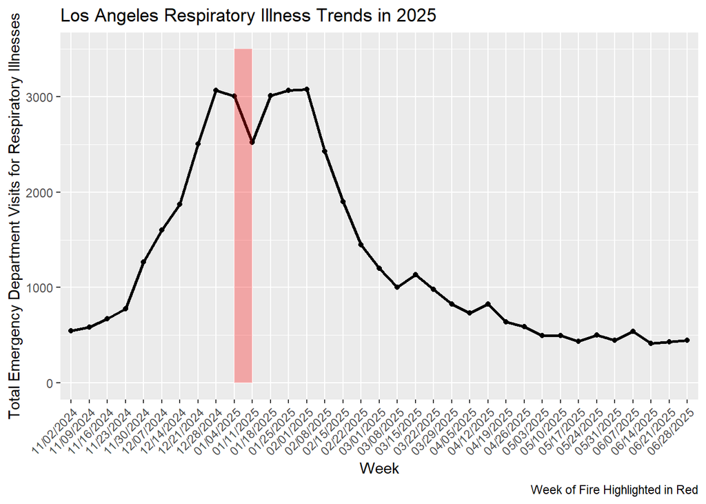

```r
Los_ang <- read_csv("data/rv-dashboard.csv")

Los_ang <- Los_ang %>%
  mutate(Los_ang = ifelse(is.na(COV_ADM), 0, COV_ADM)) %>%
  mutate(Los_ang = ifelse(is.na(FLU_ADM), 0, FLU_ADM)) %>%
  mutate(Los_ang = ifelse(is.na(RSV_ADM), 0, RSV_ADM))

LA_sum<- Los_ang %>%
  filter(RPHO_REGION == "Los Angeles") %>%
  filter(!MMWR_YEAR == "2023") %>%
  filter(SEASON == "2024/2025") %>%
  group_by(WEEKENDING) %>%
  summarise(total_ED = COV_ADM + FLU_ADM + RSV_ADM)

LA_summarise <- LA_sum %>%
  group_by(WEEKENDING) %>%
  summarise(total_ED = sum(total_ED))

LA_summarise <- LA_summarise[-c(27:43),]

last_nine <- tail(LA_summarise, 9)
remaining_rows <- head(LA_summarise, 26)
LA_summarise_correct <- rbind(last_nine, remaining_rows)

LA_summarise_correct$WEEKENDING <- as.character(LA_summarise_correct$WEEKENDING)
LA_summarise_correct$WEEKENDING <- factor(LA_summarise_correct$WEEKENDING, levels=unique(LA_summarise_correct$WEEKENDING))

La_graph <- ggplot(data = LA_summarise_correct, aes(x = WEEKENDING, y = total_ED))+
  geom_line(linewidth = 1, na.rm = T, aes(group=1))+
  geom_point()+
  theme(axis.text.x = element_text(angle = 45, hjust=1))+
  labs(x = "Week",
       y = "Total Emergency Department Visits for Respiratory Illnesses",
       title = "Los Angeles Respiratory Illness Trends in 2025",
       caption= "Week of Fire Highlighted in Red")

La_graph <- La_graph + annotate("rect", xmin = "01/04/2025", xmax = "01/11/2025", ymin = 0, ymax = 3500,
             alpha = 0.3, fill = "red")

La_graph
```

This line graph illustrates the trend in total emergency department visits for respiratory illnesses before, during, and after the 2025 Los Angeles wildfires. The wildfires began in the Palisades area during the week of January 7, 2025, and caused extensive damage across California, destroying more than 9,000 buildings and burning over 40,000 acres. The graph shows a sudden decline in respiratory-related emergency visits during the week of the wildfires. This decrease is likely due to emergency departments redirecting resources toward treating burn and trauma patients during the disaster. In the week following the wildfires, the graph indicates a slight increase in respiratory illness visits, which is consistent with expected health impacts from smoke exposure and poor air quality. This trend aligns with our prediction that wildfires would lead to an increase in respiratory illnesses; however, additional studies are needed to determine whether this increase is statistically significant.

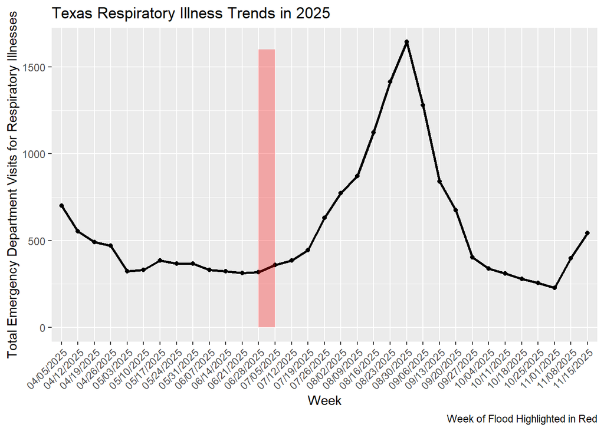

```r
texas<- read_excel("data/Weekly_ED_Visits_by_Age_Group_Data.xlsx")
texas<- texas %>%
  filter(GEOGRAPHY == "PHR 8") %>%
  filter(str_ends(WEEK_ENDING, "/2025")) %>%
  group_by(WEEK_ENDING) %>%
  summarise(total = sum(Combined_Count, na.rm = T))

texas<- texas[14:46,]

texas_graph <- ggplot(data = texas, aes(x = WEEK_ENDING, y = total))+
  geom_line(linewidth = 1, na.rm = T, aes(group=1))+
  geom_point()+
  theme(axis.text.x = element_text(angle = 45, hjust=1))+
  labs(x = "Week",
       y = "Total Emergency Department Visits for Respiratory Illnesses",
       title = "Texas Respiratory Illness Trends in 2025",
       caption= "Week of Flood Highlighted in Red")



texas_graph <- texas_graph + annotate("rect", xmin = "06/28/2025", xmax = "07/05/2025", ymin = 0, ymax = 1600,
             alpha = 0.3, fill = "red")

texas_graph
```

### How much do natural disasters affect the U.S. economy?

```r
losses <- read_csv(here("data/lnd_full_clean_2024-12-31.csv"))

losses <- losses %>%
  mutate(
    begin_date = as.Date(begin_date),
    year = year(begin_date)
  )

selected_losses <- losses %>%
  filter(event_type %in% c("Hurricane", "Flood", "Tornado", "Wildfire"))

yearly_losses <- selected_losses %>%
  group_by(year, event_type) %>%
  summarise(total_damage = sum(damages_total_adj, na.rm = TRUE)) %>%
  ungroup()
```

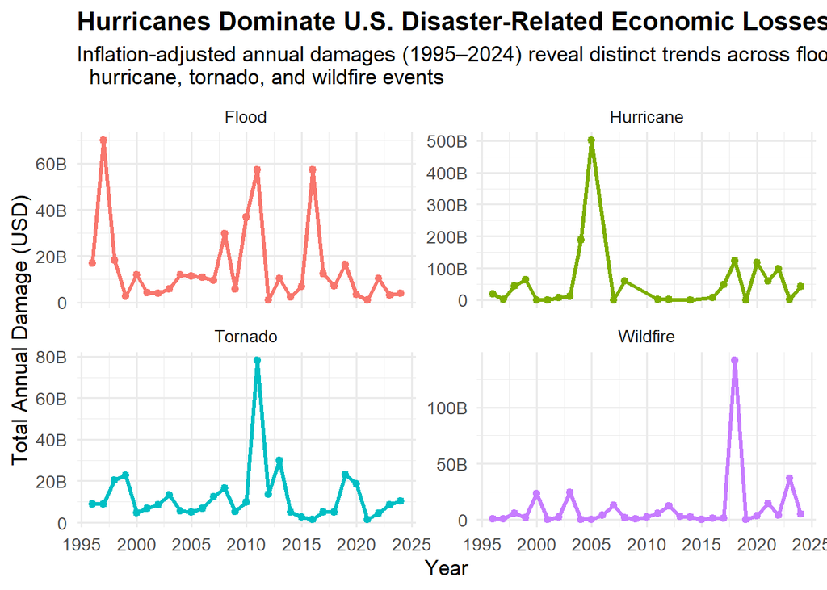

```r
ggplot(yearly_losses, aes(
  x = year,
  y = total_damage,
  color = event_type
)) +
  geom_line(linewidth = 1.2) +
  geom_point(size = 1.8) +
  scale_y_continuous(
    labels = scales::label_number(scale_cut = scales::cut_short_scale())
  ) +
  facet_wrap(~ event_type, scales = "free_y") +
  labs(
  title = "Hurricanes Dominate U.S. Disaster-Related Economic Losses",
  subtitle = "Inflation-adjusted annual damages (1995–2024) reveal distinct trends across flood,
  hurricane, tornado, and wildfire events",
  x = "Year",
  y = "Total Annual Damage (USD)"
) +
  theme_minimal(base_size = 13) +
  theme(
    plot.title = element_text(face = "bold"),
    legend.position = "none"
  )
```

Our trellis plots clearly illustrates how different types of natural disasters contribute unevenly to economic losses in the United States. Hurricanes produce by far the most extreme and volatile damages, with a historic spike in 2005 associated with Hurricane Katrina and other major storms. Flood-related losses fluctuate year to year but remain on a more moderate scale overall. Tornado damages show periodic peaks, including a sharp rise around 2011, which aligns with meteorological records showing 1,282 confirmed tornadoes in 2010 and 1,721 in 2011, one of the most active tornado years in U.S. history. Wildfire losses remain relatively low until the late 2010s, when rising fire severity leads to sharp increases in total damages. Together, these patterns highlight that the nation’s economic burden from natural hazards is driven disproportionately by rare but extremely costly hurricane and wildfire events, while tornado outbreaks contribute major but less frequent spikes.

### Which U.S. regions experience the highest economic losses from natural disasters?

```r
options(tigris_use_cache = TRUE)

counties <- counties(cb = TRUE, year = 2021)

losses <- losses %>%
  mutate(fips = str_pad(fips, width = 5, side = "left", pad = "0")) %>%
  filter(damages_total_adj > 0)

major_types <- c(
  "Flood", "Flash Flood", "Hurricane", "Tropical Storm",
  "Storm Surge/Tide", "Tornado", "Wildfire", "High Wind",
  "Winter Storm", "Thunderstorm Wind"
)

losses_major <- losses %>%
  filter(event_type %in% major_types)

county_damage <- losses_major %>%
  group_by(fips) %>%
  summarize(total_damage = sum(damages_total_adj, na.rm = TRUE))

states <- states(cb = TRUE, year = 2021)

map_data <- counties %>%
  left_join(county_damage, by = c("GEOID" = "fips"))

map_data$total_damage[is.na(map_data$total_damage)] <- 0
```

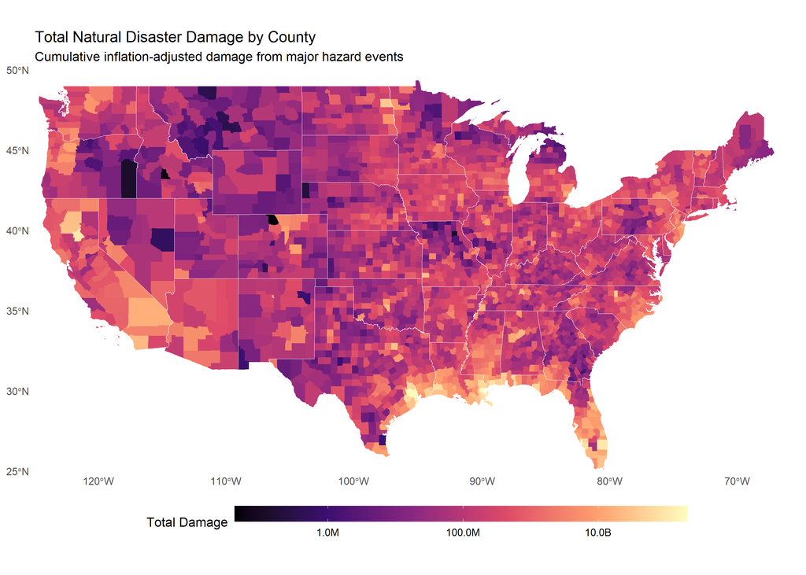

```r
ggplot(map_data) +
  geom_sf(aes(fill = total_damage), color = NA) +
  geom_sf(data = states, fill = NA, color = "white", size = 0.3) +

  scale_fill_viridis_c(
    option = "A",
    trans = "log10",
    labels = scales::label_number(
      accuracy = 0.1,
      scale_cut = scales::cut_short_scale()
    )
  ) +
  labs(
    title = "Total Natural Disaster Damage by County",
    subtitle = "Cumulative inflation-adjusted damage from major hazard events",
    fill = "Total Damage"
  ) +
  coord_sf(
    xlim = c(-125, -65),
    ylim = c(25, 50),
    expand = FALSE
  ) +
  theme_minimal(base_size = 16) +
  theme(
    legend.position = "bottom",
    legend.key.width = unit(4, "cm"),
    legend.key.height = unit(0.7, "cm"),
    panel.grid = element_blank()
  )
```

Our choropleth map of cumulative natural disaster damages reveals clear regional patterns in how economic impacts are distributed across the United States. The Gulf Coast; including Texas, Louisiana, Mississippi, Alabama, and Florida, shows consistently high levels of damage, which aligns with our prediction that this region would be the most affected due to frequent hurricanes and large-scale flooding events. The Atlantic Coast and the Northeast also exhibit elevated damages from repeated coastal storm exposure. On the West Coast, particularly in California, cumulative losses reflect the increasing severity and frequency of wildfires, an unexpectedly large economic burden that rivals the damages seen in hurricane, prone areas of the Gulf. In contrast, much of the Midwest and northern interior display substantially lower cumulative damages, with only isolated counties experiencing significant losses. One surprising pattern is the presence of several inland counties that show unexpectedly high damage totals despite being far from the coasts, suggesting that severe localized floods or tornado outbreaks can create greater economic impacts than typically assumed. Overall, the map highlights a clear geographic divide: coastal regions face concentrated and recurrent economic risks, while inland areas tend to experience far fewer high-damage events.

### What disasters cause the most deaths?

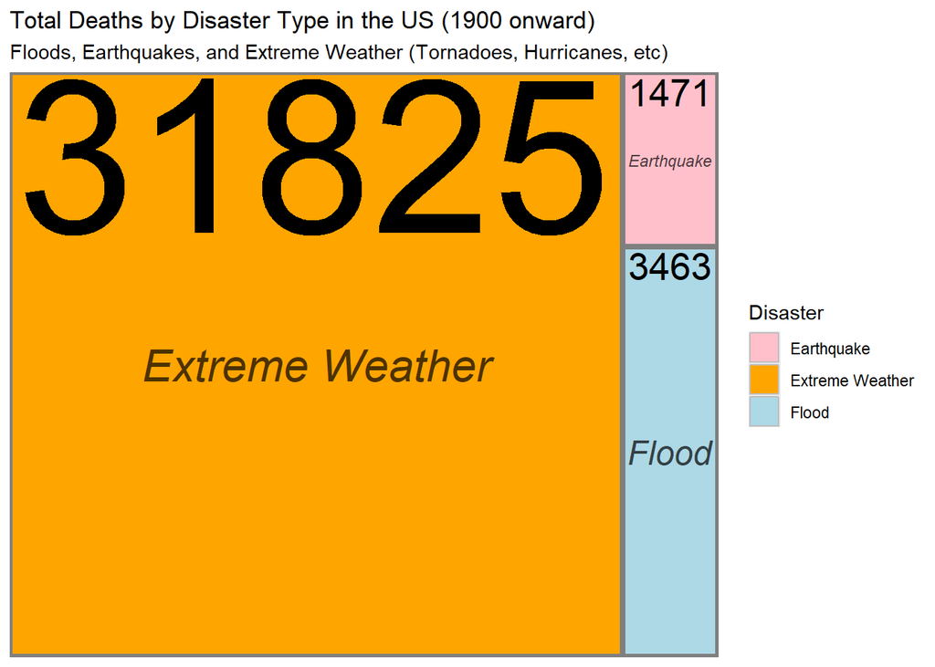

```r
deaths <- read_csv(here("data/number-of-deaths-by-disaster.csv"))

deaths_usa <- deaths %>%
  filter(Entity == "United States") %>%
  select(Year,
         `Deaths - Flood`,
         `Deaths - Earthquake`,
         `Deaths - Extreme weather`)

long_data <- deaths_usa %>%
  pivot_longer(cols = -Year, names_to = "Disaster", values_to = "Deaths") %>%
  mutate(Deaths = ifelse(is.na(Deaths), 0, Deaths))

total_data <- long_data %>%
  group_by(Disaster) %>%
  summarise(Total_Deaths = sum(Deaths))

total_data <- total_data %>%
  mutate(Disaster = recode(Disaster,
                                      "Deaths - Earthquake" = "Earthquake",

"Deaths - Extreme weather" = "Extreme Weather",
"Deaths - Flood" = "Flood"
))

ggplot(data=total_data, aes(
  area = Total_Deaths,
  fill = Disaster,
  subgroup = Disaster,
  label = Total_Deaths
)) +
  geom_treemap() +
  geom_treemap_subgroup_border()+
  geom_treemap_subgroup_text(place = "centre",
                             size = 24,
                             alpha = 0.7,
                             colour="black",
                             fontface="italic")+
  geom_treemap_text(
    place = "topleft",
    colour = "black",
    grow = TRUE
  ) +
  scale_fill_manual(values = c(
    "Flood" = "lightblue",
    "Earthquake" = "pink",
    "Extreme Weather" = "orange"
  )) +
  labs(title = "Total Deaths by Disaster Type in the US (1900 onward)",
       subtitle = "Floods, Earthquakes, and Extreme Weather (Tornadoes, Hurricanes, etc)")
```

### What disasters cause the highest numbers of homelessness?

[figure not shown]

```r
homeless <- read_csv(here("data/number-homeless-from-natural-disasters.csv"))

three_types <- homeless %>%
  group_by(Entity) %>%
  summarise(total_homeless = sum(Homeless, na.rm = TRUE)) %>%
  filter(Entity %in% c("Extreme weather", "Flood", "Wildfire")) %>%
  mutate(Disaster = Entity)

all_disasters <- homeless %>%
  group_by(Entity) %>%
  summarise(total_homeless = sum(Homeless, na.rm = TRUE)) %>%
  filter(Entity == "All disasters") %>%
  mutate(Disaster = Entity)

ggplot(data = three_types,
       aes(x = Disaster,
           y = total_homeless / 1000,
           fill = Disaster))+
  geom_bar(stat = "identity") +
  geom_text(aes(label = total_homeless/10000, vjust = -0.5)) +
  scale_y_continuous(limits = c(0, 125000)) +
  labs(title = "Cases of Homelessness by Disaster (in tens of thousands, 1900 onwards)",
       x = "Type of Disaster",
       y = "Cases (tens of thousands)")
```

## Conclusion

Overall, the evidence demonstrates that natural disasters significantly affect both human welfare and economic resilience in the United States, with their impacts varying widely across regions and hazard types. This highlights the need for region-specific preparedness strategies and long-term planning that considers not only immediate damage but also ongoing health and housing consequences.

## Contributions

### Kaya Williams

- How do rates of respiratory symptoms change after natural disasters? charts
- Narrative and results of How do rates of respiratory symptoms change after natural disasters? charts
- Created slides for above chart

### Akillesh Suresh

- Wrote the introduction and conclusion paragraphs
- Which U.S. regions experience the highest economic losses from natural disasters? chart
- How much do natural disasters affect the U.S. economy? chart
- Narrative and results of Which U.S. regions experience the highest economic losses from natural disasters? chart
- Narrative and results of How much do natural disasters affect the U.S. economy? chart
- Created slides for above charts

### Alyssa Girard

- What disasters cause the most deaths? chart
- What disasters cause the highest rates of homelessness? chart
- Narrative and results of What disasters cause the highest rates of homelessness? chart
- Narrative and results of What disasters cause the most deaths? chart
- Created slides for above charts

## Appendix: Data Dictionary

```r
knitr::kable(data_dictionary)
```

| Variable_Name | Description |
| --- | --- |
| Entity | Country or region represented in the dataset. |
| Year | Year of the recorded disaster event. |
| Deaths - Flood | Number of deaths caused by floods in a given year. |
| Deaths - Extreme weather | Number of deaths from extreme weather events. |
| Deaths - Earthquake | Number of deaths caused by earthquakes. |
| Homeless | Number of people left homeless due to a disaster. |
| Injured | Number of people injured due to disasters. |
| fips | County FIPS code identifying U.S. counties. |
| event_type | Type of natural disaster. |
| begin_date | Date when the disaster event began. |
| damages_total_adj | Inflation-adjusted total economic damages for the event. |
| county | County where the event occurred. |
| state | State where the county is located. |
| Week_of | Date the weekly reporting period begins. |
| COVID-like Illness | Emergency visits classified as COVID-like illness. |
| RSV-like Illness | Emergency visits classified as RSV-like illness. |
| Influenza | Emergency visits associated with influenza. |
| Combined_Count | Total emergency department visits across illness types. |
| RPHO_REGION | Public Health Region identifier. |
| WEEKENDING | End date of the reporting week. |